# ecoforge_Rpackage example

**Authors**  
David Ferrer Ferrando, Pelayo Acevedo & Pedro Tarroso

**Published**  
2024/03/19 - 2026/05/27

[figure not shown]

# Case Study: Simulating virtual species and sampling designs with the ecoforge package

In this vignette we present a complete case study illustrating how to use the *ecoforge* package to build spatially explicit simulations of virtual species. This type of virtual ecology framework is particularly useful for evaluating spatial ecology models (such as species distribution models or occupancy models) under known and controlled conditions. For example evaluating the effect of different sampling strategies on model performance, or generating reproducible synthetic datasets for methodological research in ecology.

To facilitate the comprehension of the full simulation workflow and the possibilities offered by the package functions, the example is structured in the following steps:

1. **Install and load the required packages** (ecoforge and dependencies).
2. **Generate the environmental spatial layers**, and modify or transform them to define habitat characteristics of the study area.
3. **Define the target species’ habitat suitability**, combining environmental layers to build a spatial suitability surface.
4. **Generate the species’ distribution**, placing individuals across the study area according to habitat suitability, and optionally introducing possible distribution bias.
5. **Sample the species’ distribution**, designing the survey strategy (point counts or line transects, random or uniform sampling units), and obtaining count or presence/absence (or detection/non-detection) data.
6. **Export the simulated data** in formats ready for use in ecological models.
7. **Additional tip** assessing correlation between environmental variables before model fitting.

To see more about *ecoforge* package (and other *vignettes*) see [ecoforge website](https://natureprotectiondff.github.io/Ecoforge-R-package/)

## 1. Getting started

First of all, install and load *ecoforge* package and all the dependencies required for the correct function of these simulations.

```r
# install.packages("dismo")
# install.packages("fields")
# install.packages("devtools")
# devtools::install_github("NatureProtectionDFF/Ecoforge-R-package")
library(ecoforge)
library(dismo)
library(fields)

set.seed(1234) # To create reproducible results
```

## 2. Generate the environmental spatial layers

These functions let us control and determine some parameter values that define spatial variables. Inside of these functions, we employ a previous developed function `gstat()` of the package **gstat**.

### 2.1 Climate variables

We start creating clime conditions. To do this, we have a first function `generateClim()` that allows us to create climate variables (in this case, temperature and precipitation). When creating these variables, several parameters can be controlled, such as the mean value `Tmean & Pmean`, the range of variation `Tsd & Psd`, and the range of spatial autocorrelation `Trange & Prange`. For temperature, daily and annual ranges are also considered `T_amp & T_ar`, both with maximum and minimum range values. Precipitation also follows an annual range `Pav`. Both annual ranges follow a latitudinal gradient: in this case, the higher the latitude, the greater the range. To learn more about the different components of this function (and the following ones), read the description and details of the function available on the website, [ecoforge Functions reference](https://natureprotectiondff.github.io/Ecoforge-R-package/#functions-reference).

```r
clim <- generateClim(nrow=200, ncol=200, Tmean=15, Tsd=4, Trange=45,
                     Tamp_max=10, Tamp_min=1, Tar_max=10, Tar_min=5,
                     Pmean=500, Psd=300, Prange=45, Pav_max=50,
                     Pav_min=10)
```

```
[using unconditional Gaussian simulation]
[using unconditional Gaussian simulation]
[using unconditional Gaussian simulation]
```

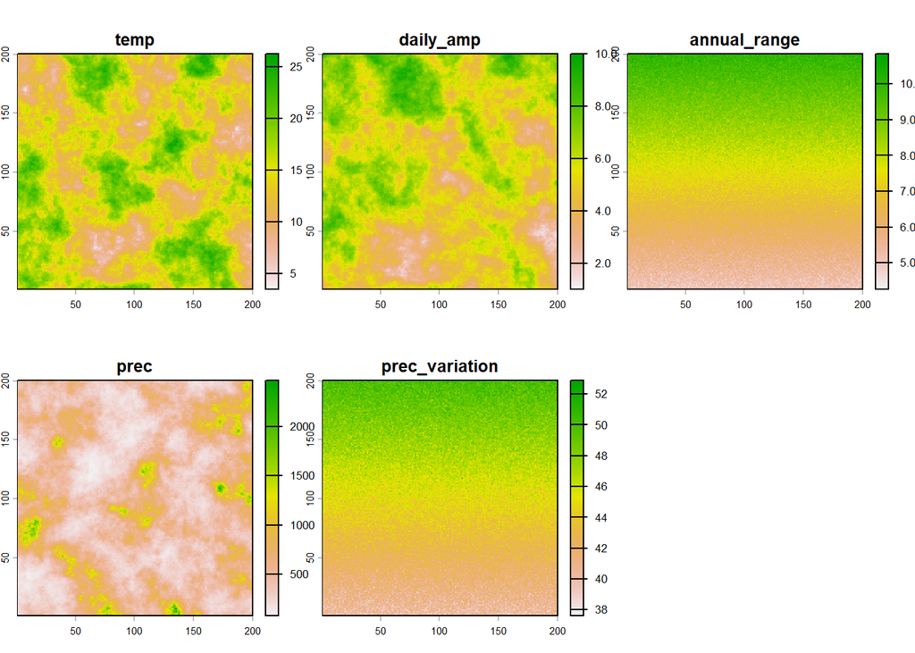

```r
clim_rst <- rast(clim, type="xyz")
cols <- rev(terrain.colors(100))
plot(clim_rst, col= cols)
```

```r
clim_rst <- c(clim_rst$temp, clim_rst$prec) #save a raster with only mean Temperature and mean precipitation
```

But what we have obtained is an average value in a fixed image (a single value per cell). In this fixed image, we have a single value per cell. To obtain a value that varies throughout the year for each cell, we create monthly values for temperature and precipitation with the `generateMonthlyTemp()` and `generateMonthlyPrec()` functions, respectively. In the case of temperature, we will obtain a maximum, average, and minimum temperature for each month. In the case of precipitation, we obtain the cumulative value for each month. The daily and annual high and low values are determined by the values assigned within the ranges we set before.

```r
m_temp <- generateMonthlyTemp(clim$temp, clim$daily_amp, clim$annual_range, err_sdev=1)
```

```
Generating data for January
Generating data for February
Generating data for March
Generating data for April
Generating data for May
Generating data for June
Generating data for July
Generating data for August
Generating data for September
Generating data for October
Generating data for November
Generating data for December
```

```r
m_prec <- generateMonthlyPrec(clim$prec, clim$prec_variation, err_sdev=0.1)
```

Here we can visualize this temperature monthly variation (minimum, maximum and average) represented by the mean of all the cells simulated.

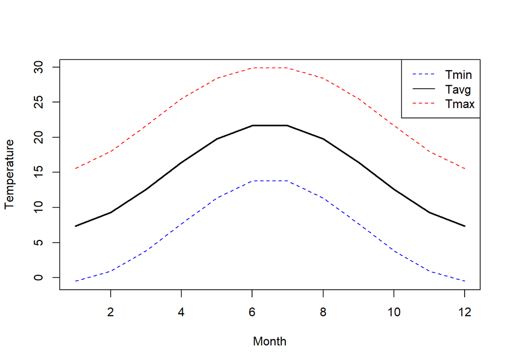

```r
#Extract each type of temperature data (min, max and average) and obtain the mean value for all the simulated area
tmin <- colMeans(m_temp$tmin, na.rm=TRUE)
tavg <- colMeans(m_temp$tavg, na.rm=TRUE)
tmax <- colMeans(m_temp$tmax, na.rm=TRUE)

#Visualize the average temperature
plot(1:12, tavg, type="l", col="black", lwd=2,
     ylim=range(c(tmin, tmax)),
     xlab="Month", ylab="Temperature")

#Add min and max temperature values
lines(1:12, tmin, col="blue", lty=2)
lines(1:12, tmax, col="red", lty=2)

#Add the legend
legend("topright",
       legend=c("Tmin","Tavg","Tmax"),
       col=c("blue","black","red"),
       lty=c(2,1,2))
```

And here we show the monthly variation in accumulated precipitation. It can be observed that the months with higher temperatures coincide with lower precipitation levels. This pattern reflects the characteristics of a Mediterranean ecosystem.

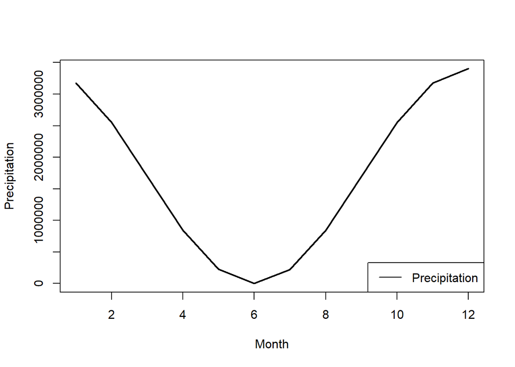

```r
#Obtain the accumulated value
s_prec <- colSums(m_prec, na.rm=TRUE)

#Visualize the average temperature
plot(1:12, s_prec, type="l", col="black", lwd=2,
     ylim=range(c(min(s_prec), max(s_prec))),
     xlab="Month", ylab="Precipitation")

#Add the legend
legend("bottomright",
       legend="Precipitation",
       col="black",
       lty=1)
```

All of this information, in addition to being useful in itself, can also be used to create other types of covariates. To generate the standard bioclimatic variables available in open-source databases, we need the monthly values for cumulative precipitation, along with the maximum and minimum temperatures for each month. To derive these variables from the data, we use the `biovars()` function from the **dismo** package.

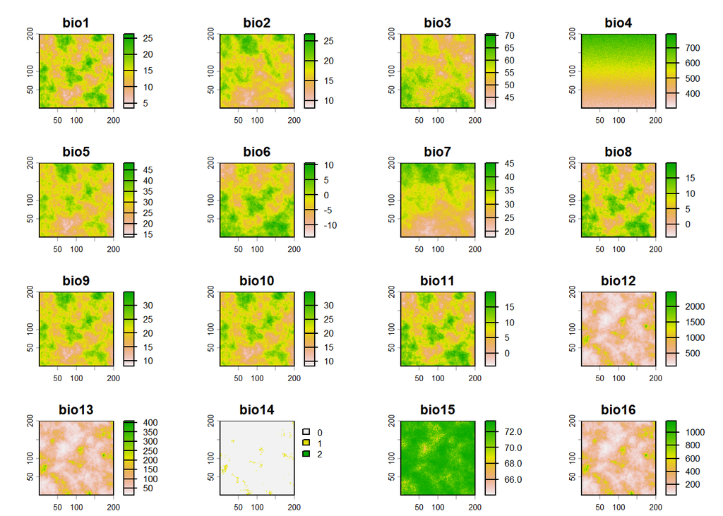

```r
bv <- biovars(prec=m_prec, tmin=m_temp$tmin, tmax=m_temp$tmax)
bv_rst <- rast(cbind(clim[,1:2], bv), type="xyz")
plot(bv_rst, col= cols)
```

### 2.2 Non-climate variables

But if we want to create other types of environmental (non-climate) variables, we can use another function, `generateVarb()`. Just as we did with the climate variables, here we can also assign the mean value `Vmean`, its range of variation `Vsd`, and the range of spatial autocorrelation `Vrange`. It can be used like any other type of variable (e.g., human footprint, vegetation, percentage of pollutants in the soil, or distribution of another species). For this example we consider it as vegetation.

```r
vegt <- generateVar(nrow=200, ncol=200, Vmean=8, Vsd=3, Vrange=10)
```

```
[using unconditional Gaussian simulation]
```

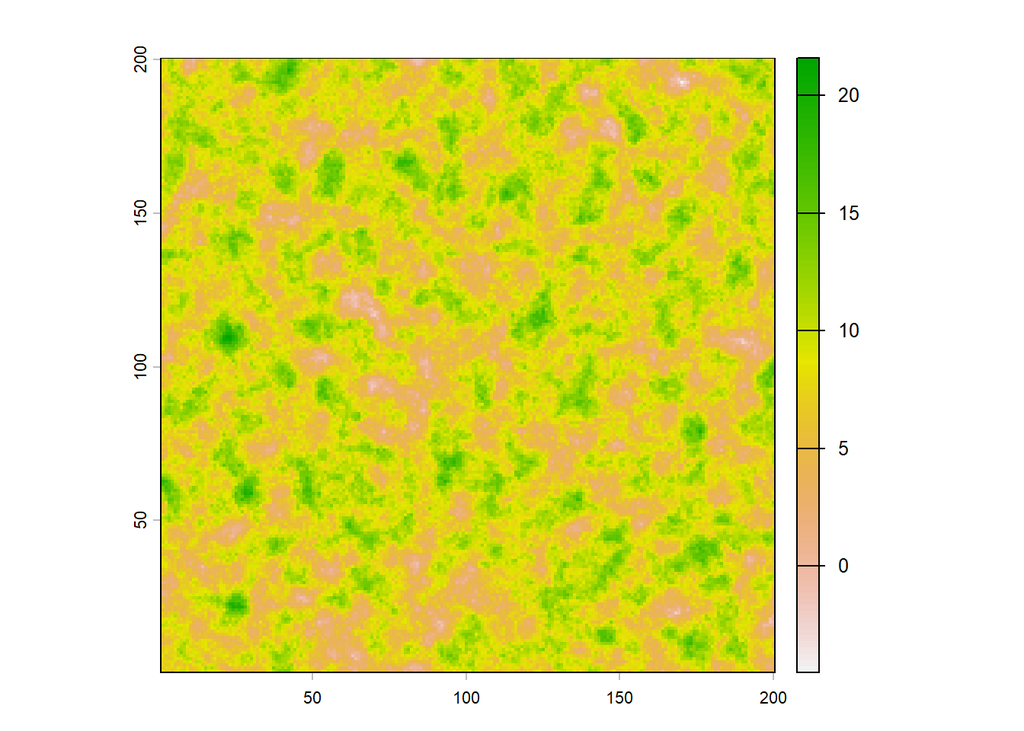

```r
vegt_rst <- rast(vegt, type="xyz")
plot(vegt_rst, col= cols)
```

### 2.3 Edit environmental variables

Once the layers have been created, we can modify certain aspects. For example, we can create a reference layer with the desired attributes and use it to modify those attributes in the layers we’re interested in. In this case, we’re going to change the extent.

```r
#Create the reference layer
r_base.t <- rast(ncol=200, nrow=200, xmin=-0, xmax=200, ymin=0, ymax=200)

#Change the extension of the predictors created above
bv_rst@pntr[["extent"]] <- r_base.t@pntr[["extent"]]
clim_rst@pntr[["extent"]] <- r_base.t@pntr[["extent"]]
vegt_rst@pntr[["extent"]] <- r_base.t@pntr[["extent"]]
```

Another thing we can do is change the resolution of the layers. In this case, we can reduce the resolution using the `aggregate()` function from the **Terra** package.

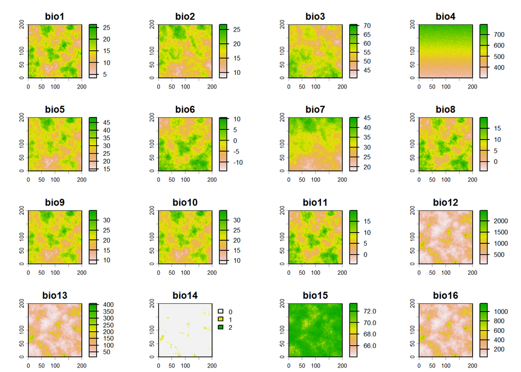

```r
#climate variables
bv_40 <- aggregate(bv_rst, fact = 5, fun = mean)  #from raster 200x200 units to raster 40x40 units
bv_20 <- aggregate(bv_rst, fact = 10, fun = mean) #from raster 200x200 units to raster 20x20 units
plot(bv_rst, col= cols)
```

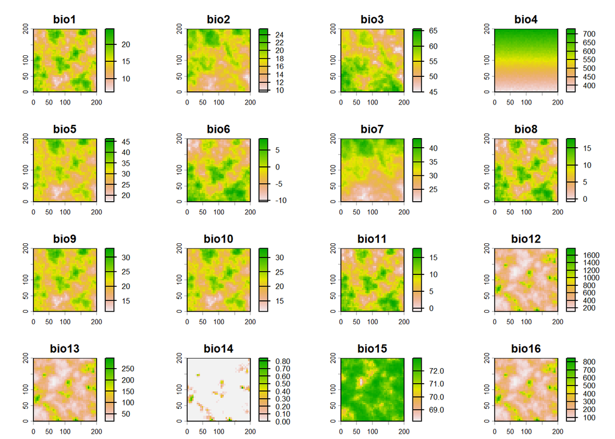

```r
plot(bv_40, col= cols)
```

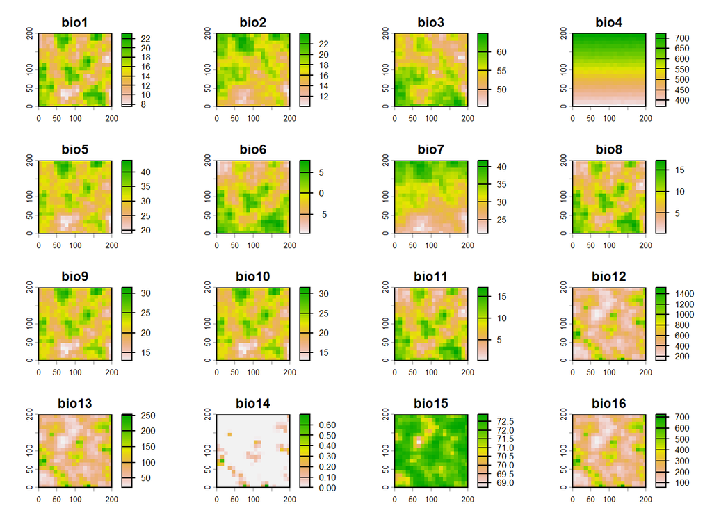

```r
plot(bv_20, col= cols)
```

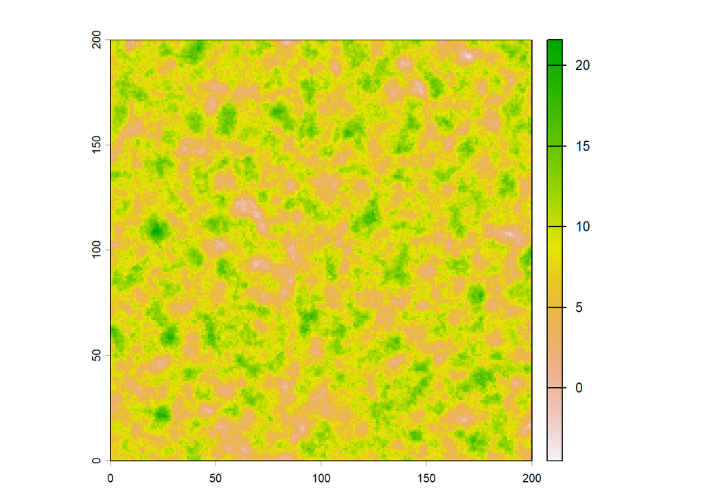

```r
#vegetation variable
vegt_40 <- aggregate(vegt_rst, fact = 5, fun = mean)  #from raster 200x200 units to raster 40x40 units
vegt_20 <- aggregate(vegt_rst, fact = 10, fun = mean) #from raster 200x200 units to raster 20x20 units
plot(vegt_rst, col= cols)
```

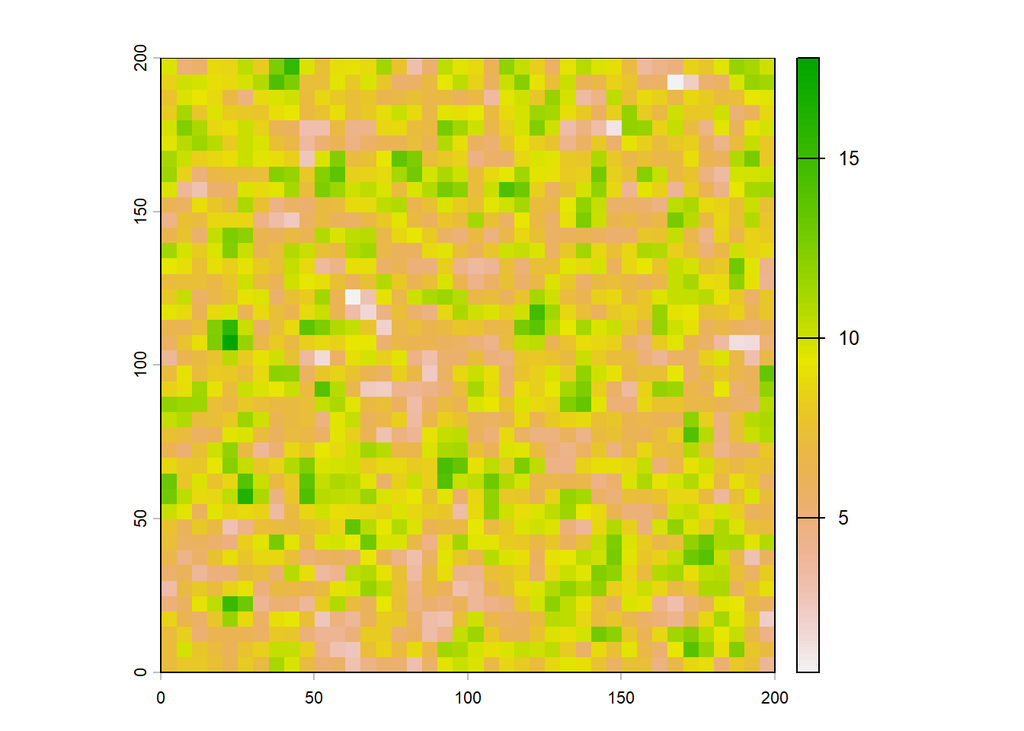

```r
plot(vegt_40, col= cols)
```

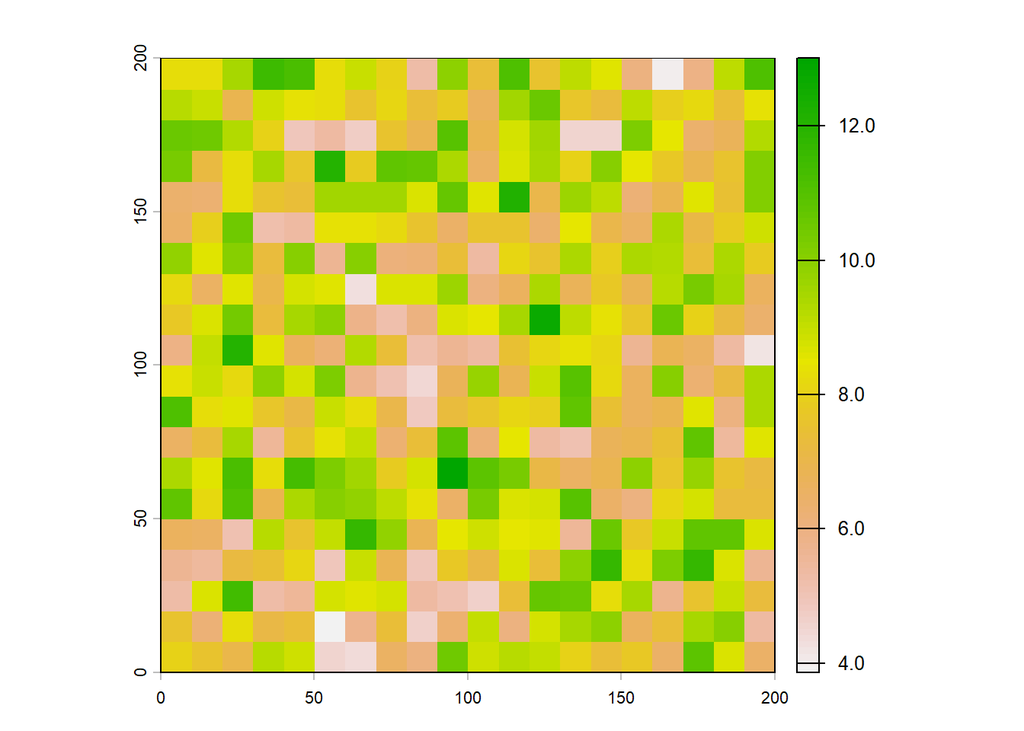

```r
plot(vegt_20, col= cols)
```

## 3. Define the target species’ habitat suitability (or expected abundance)

In this section, we are going to simulate a layer that indicates the suitability of each cell for a target species, based on previously defined predictor variables (such as those we just created in the previous section).

To do this, we start by standardizing all the predictor variables to ensure that each one contributes equally to the model, regardless of the variable’s range and scale.

```r
#vegetation variables
vegt_std <- scale(vegt_rst)
vegt40_std <- scale(vegt_40)
vegt20_std <- scale(vegt_20)

#climate variables
clim_std <- scale(clim_rst)

#bioclim variables (what we usually have available when collect data)
bv_std <- scale(bv_rst)
bv40_std <- scale(bv_40)
bv20_std <- scale(bv_20)
```

To develop this simulation, we want to account for a certain margin of error. That is why we created an error layer with a normal distribution.

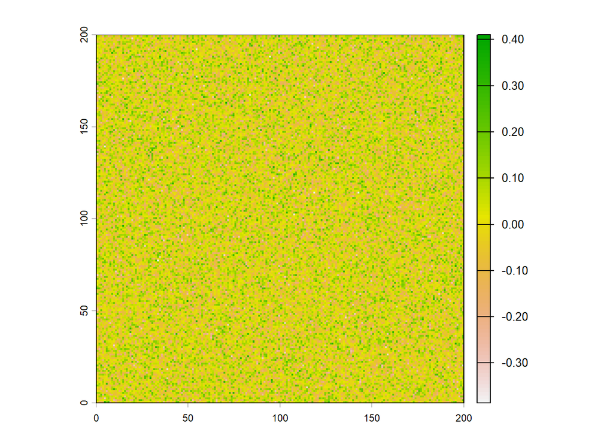

```r
r_error <- bv_std$bio1
r_error[] <- rnorm(ncell(r_error), mean = 0, sd = 0.1)
plot(r_error, col= cols)
```

Once we have all the necessary components, we proceed to simulate the suitability layer for our target species (*LAMBDA*, which will show the spatial distribution pattern of our species). To do this, we use a **Generalized Linear Model (GLM)**. For this example, we have considered the temperature, precipitation, and vegetation predictor layers as independent variables, but we could also use the bioclimatic layers we have created, other layers we might want to create, or even existing layers that have been adjusted with the same attributes. It is also important to note that when simulating this *LAMBDA*, different weights can be applied to each variable, as demonstrated in another vignette available on GitHub, [Ferrer-Ferrando et. al., 2025, Ecography example](https://natureprotectiondff.github.io/Ecoforge-R-package/vignettes/Ferrer-Ferrando_etal_Ecography/Simulation.vignette.html).

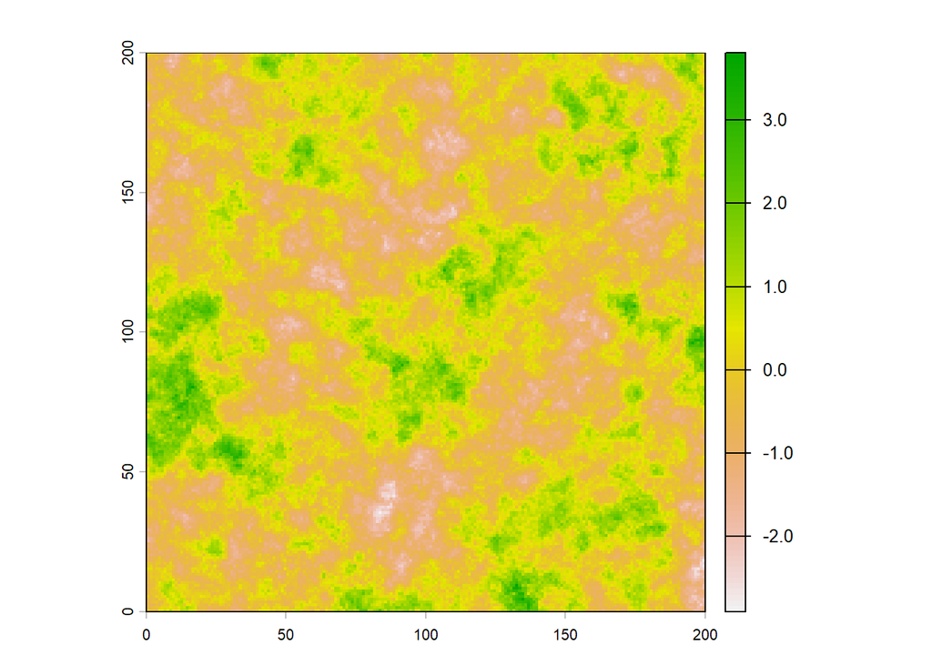

```r
LAM <- 0.5*clim_std$temp + 0.5*clim_std$prec + 0.5*vegt_std + r_error

plot(LAM, col= cols)
```

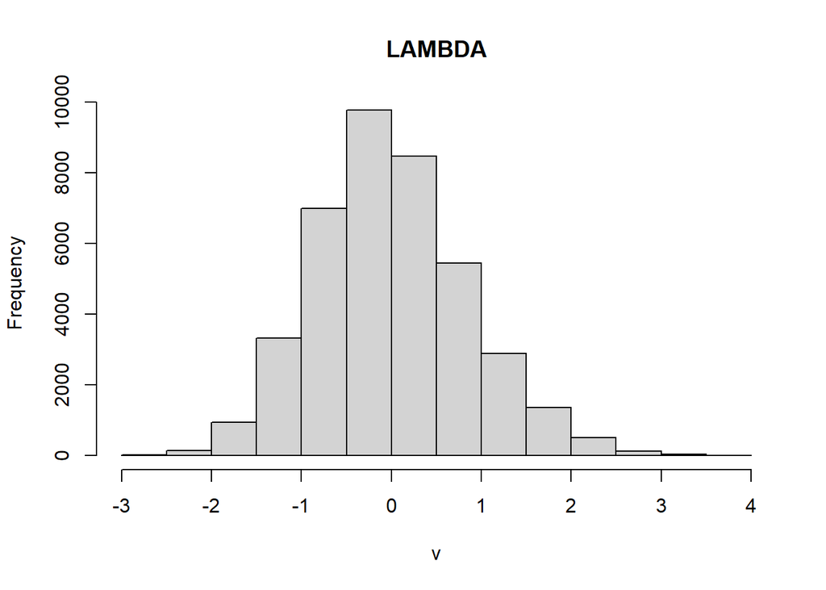

```r
hist(LAM, main="LAMBDA")
```

However, we see that this result shows both negative and positive values for *LAMBDA*, and follows a normal distribution (many intermediate values and few values at the extremes). For this reason, we have developed the `logistic()` function, which performs a logistic transformation on this distribution. With this transformation, we are able to address both issues: 1) We can define the range of values that LAMBDA takes, starting at zero and setting the maximum value we want (`L`; in this example, we have set it to 1); 2) And we can better highlight the optimal areas from the less optimal ones, obtaining more values at the extremes and fewer in the center (in this example, considering a scenario with many zeros and low values, and the rest more uniform). This second part can be adjusted using two components: the point of inflection `x0`, and the softness of the curve `k`.

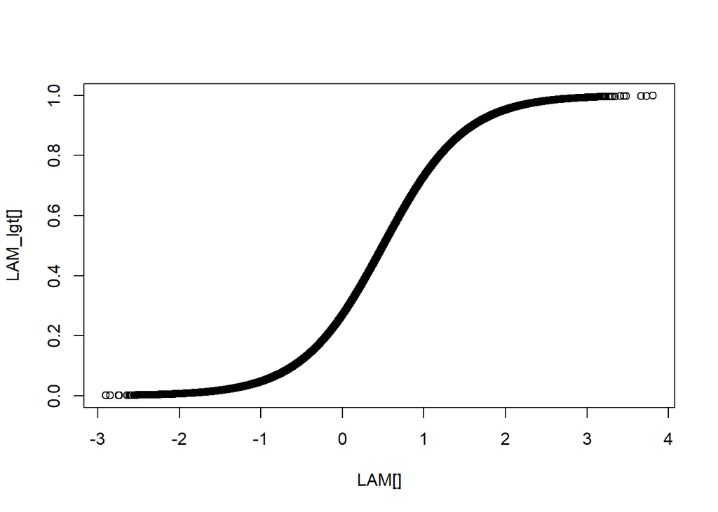

```r
LAM_lgt <- logistic(LAM, x0 = 0.5, L = 1, k = 2)

par(mfrow = c(1,1))
plot(LAM[], LAM_lgt[]) #visualize the relationship between original and transformed data
```

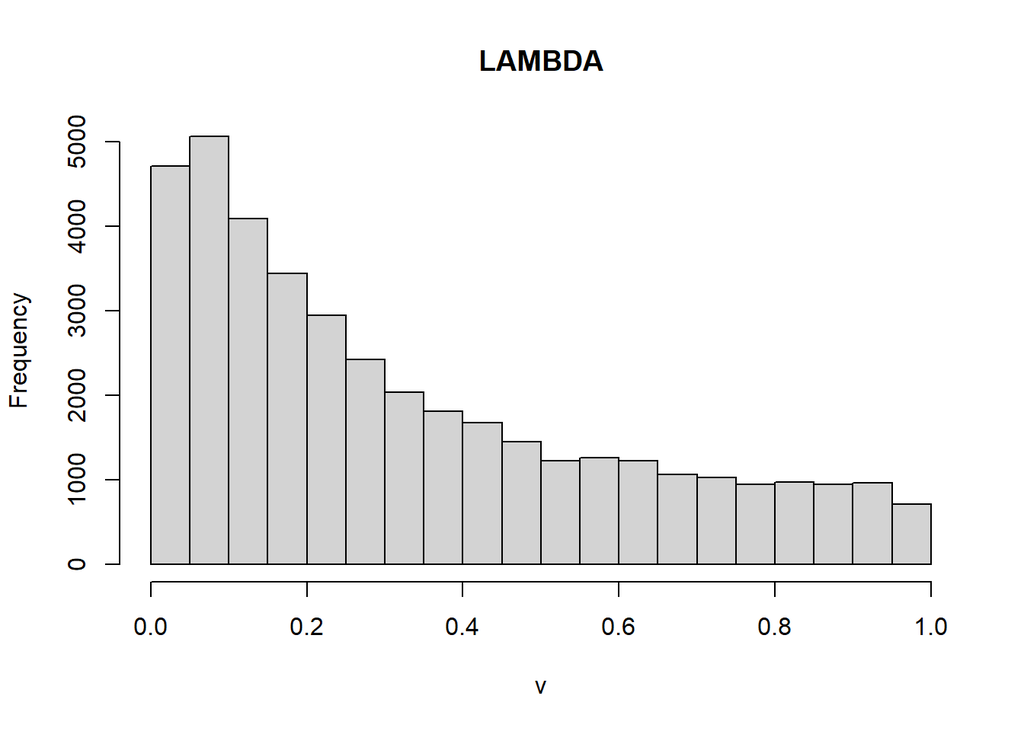

```r
hist(LAM_lgt, main="LAMBDA")
```

The point of inflection `x0` refers to the value within the range where the curve of the logistic function changes. With this transformation, we can also obtain species with higher or lower range of suitable conditions. For example, small range may represent specialist species (with narrow suitable conditions), whereas wide range may represent generalist species (with broader suitable conditions).

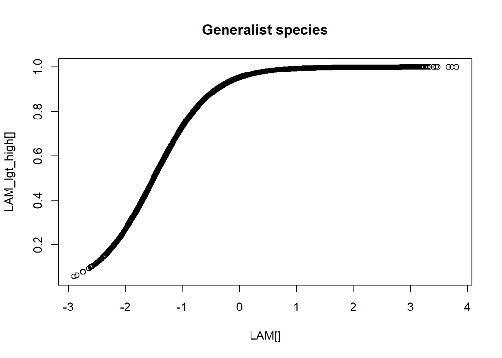

```r
#High tolerance example
LAM_lgt_high <- logistic(LAM, -1.5, 1, 2)

par(mfrow = c(1,1))
plot(LAM[], LAM_lgt_high[], main="Generalist species")
```

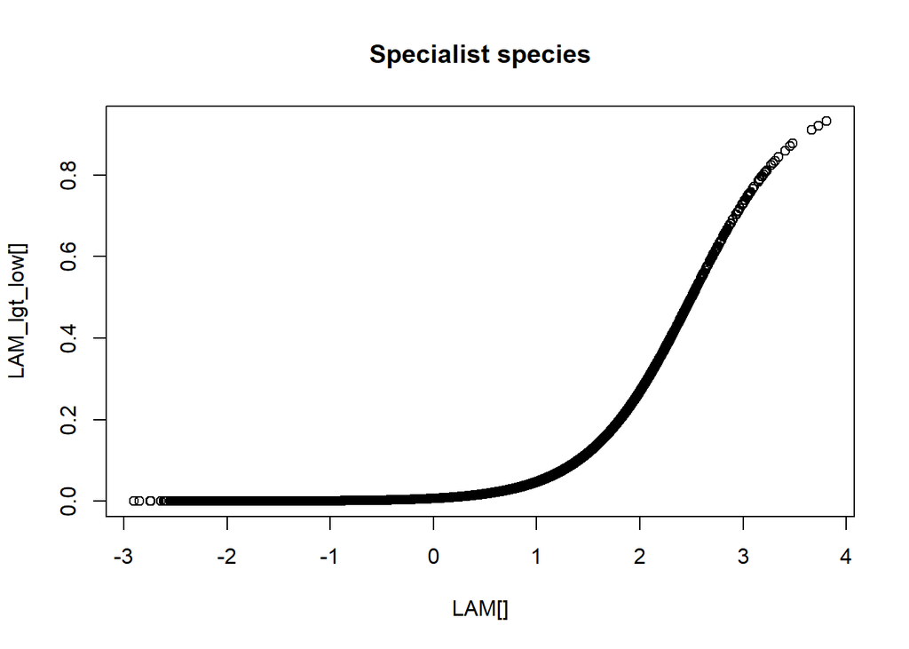

```r
#Low tolerance example
LAM_lgt_low <- logistic(LAM, 2.5, 1, 2)

par(mfrow = c(1,1))
plot(LAM[], LAM_lgt_low[], main="Specialist species")
```

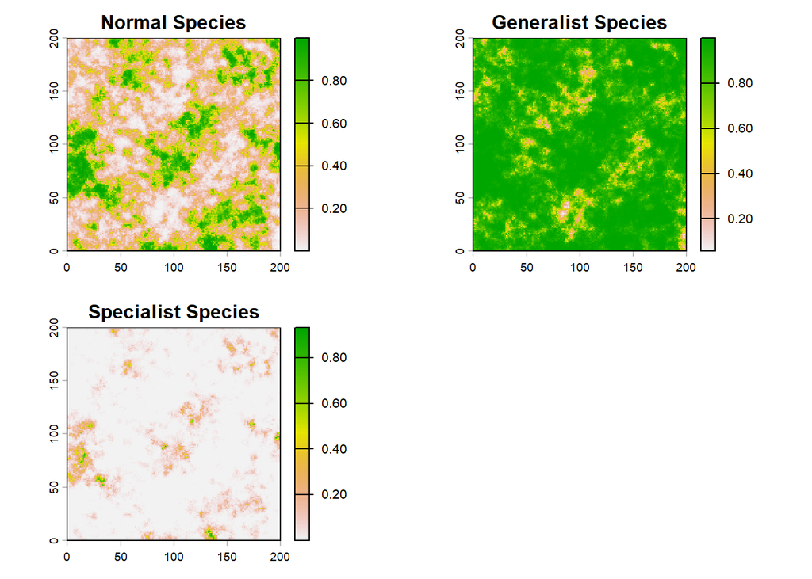

```r
#Map visualization of "normal", "specialist", and "generalist" species
par(mfrow = c(2,2))
plot(LAM_lgt, main="Normal Species", col= cols)
plot(LAM_lgt_high, main="Generalist Species", col= cols)
plot(LAM_lgt_low, main="Specialist Species", col= cols)

rm(LAM_lgt_high)
rm(LAM_lgt_low)
```

The softness of the curve `k` indicates the degree of variation along the point of inflection, with the curve being either more abrupt or smoother. This can also refer to the species’ tolerance, where a more gradual change indicates a species that is more tolerant of unfavorable conditions, while an abrupt change indicates a species that is less tolerant of unfavorable conditions.

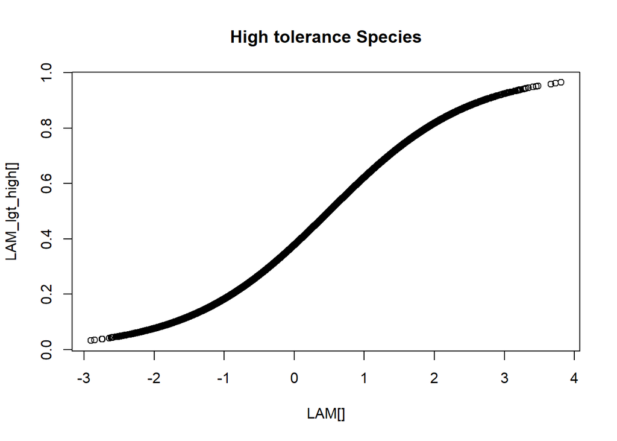

```r
#High tolerance example
LAM_lgt_high <- logistic(LAM, 0.5, 1, 1)

par(mfrow = c(1,1))
plot(LAM[], LAM_lgt_high[], main="High tolerance Species")
```

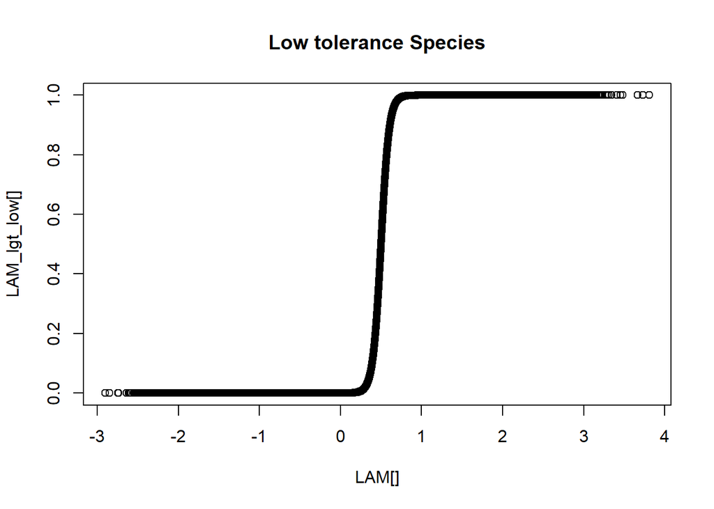

```r
#Low tolerance example
LAM_lgt_low <- logistic(LAM, 0.5, 1, 20)

par(mfrow = c(1,1))
plot(LAM[], LAM_lgt_low[], main="Low tolerance Species")
```

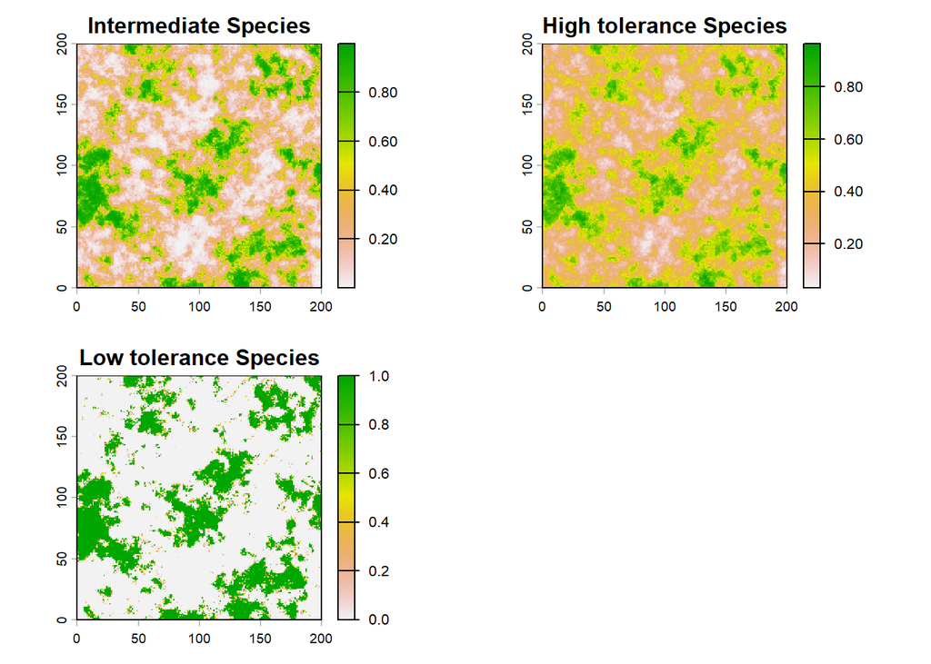

```r
#Map visualization of "normal", "specialist", and "generalist" species
par(mfrow = c(2,2))
plot(LAM_lgt, main="Intermediate Species", col= cols)
plot(LAM_lgt_high, main="High tolerance Species", col= cols)
plot(LAM_lgt_low, main="Low tolerance Species", col= cols)

rm(LAM_lgt_high)
rm(LAM_lgt_low)
```

However, even after the logistic transformation, we still do not have exact zero values (they are very low, but not zero). To address this, we need to round the values to obtain them.

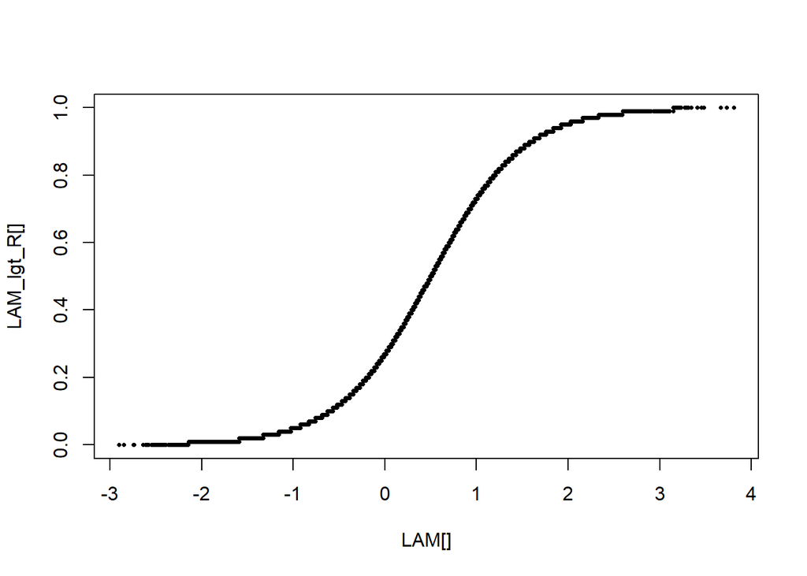

```r
LAM_lgt_R <- round(LAM_lgt, 2)

plot(LAM[], LAM_lgt_R[], pch = 16, cex = 0.5) #visualize the relationship between original and transformed data rounded
```

To conclude this section, here is a comparison of the maps showing the original *LAMBDA* value and both transformations (logistic and rounding).

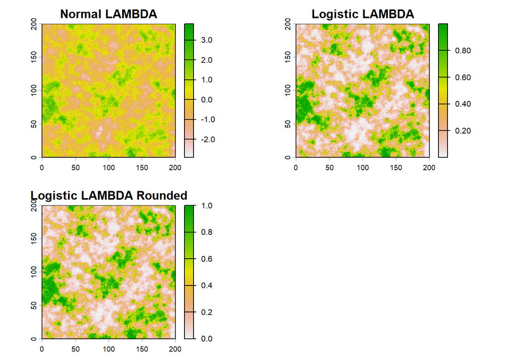

```r
par(mfrow = c(2,2))
plot(LAM, main="Normal LAMBDA", col= cols)
plot(LAM_lgt, main="Logistic LAMBDA", col= cols)
plot(LAM_lgt_R, main="Logistic LAMBDA Rounded", col= cols)
```

## 4. Generate the species’ distribution

In this section, our goal is to generate the species’ distribution in point format, representing individuals of the species in our study area.

### 4.1 Generate individual presences

Using the `generatePoints()` function, we can distribute the individuals based on the suitability layer we obtained earlier, following a **Poisson Point Process**. With this function, you can specify the number of animals you want to generate `npoints` (as long as the layer contains values between 0 and 1).

```r
#Create the dots (individuals in space)
occurs <- generatePoints(LAM_lgt_R, npoints = 40000)
occurs
```

```
Planar point pattern: 40011 points
window: rectangle = [0, 200] x [0, 200] units
```

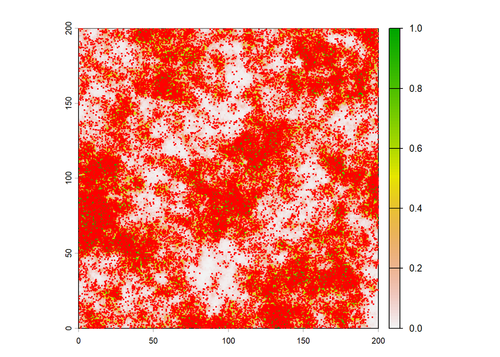

```r
#Visualize the individuals on the maps
par(mfrow = c(1,1))
plot(LAM_lgt_R, col= cols)
points(occurs, cex = 0.3, pch=19, col='red')
```

### 4.2 Bias the distribution of individuals

If we want to simulate a bias in the distribution of the individuals on the spatial area (because lack of equilibrium with the environment), or a bias in the sampling process (like in real cases occur sometimes), we can do it removing some points (randomly, based on abundance values or by other causes or covariates).

First, we start choosing the number of individuals that we are going to keep based on percentage

```r
xy <- data.frame(cbind(occurs$x, occurs$y)) #extract the coordinates of each dot (individual)
occurssp <- SpatialPoints(xy) #transform to spatial object
occurssp@bbox #see the extention of the dots
```

```
            min      max
X1 0.0006515658 199.9976
X2 0.0002552627 199.9752
```

```r
n <- occurs$n*0.3 #determine the number of dots that we want to keep.
n <- round(n, 0) #round to a complete number (not decimal)
```

Now, using the percentage indicated above, we choose this percentage from the total number of presences based on probability (could be based on spatial covariates or coordinates axes, between others)

#### 4.2.1 Bias based on coordinate axis

In this case we determine that the x axis determine the probability of presence of the individuals, where lower values on the x axis determine lower probability of presence of individuals.

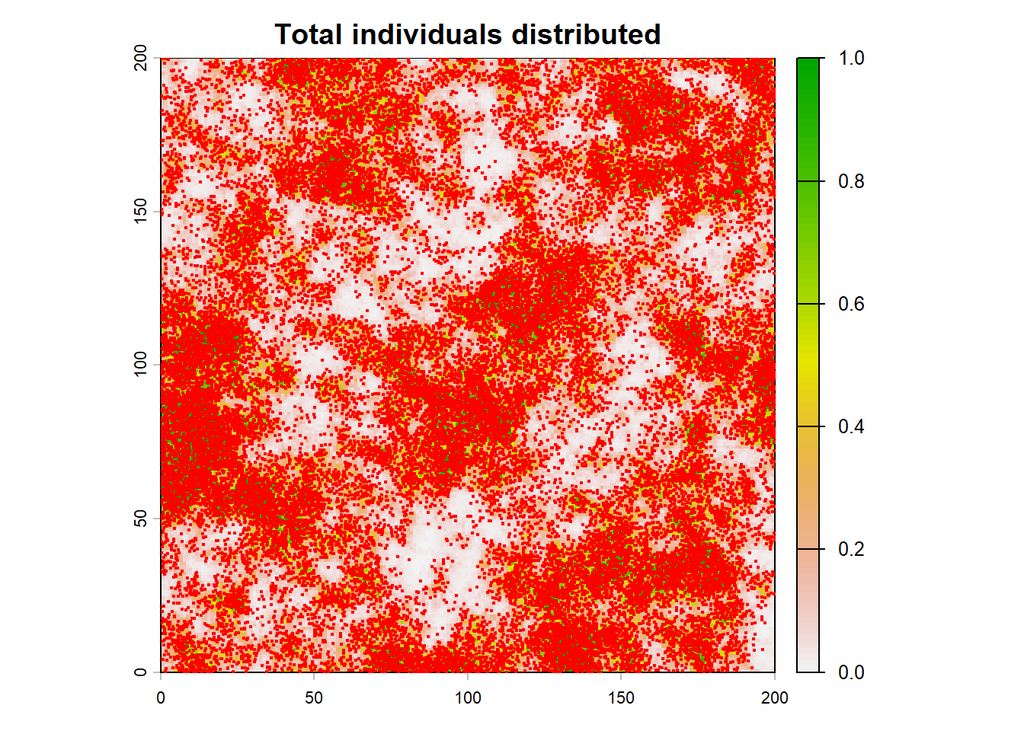

```r
#Select from the total of individuals distributed in the space, the percentage indicated (size) based on the x axis probability (prob)
sampled <- sample(occurssp, size = n, prob = occurs$x)
xy <- data.frame(sampled@coords); names(xy) <- c("x", "y")
samp_ppp <- ppp(xy$x, xy$y, window = occurs$window)

#Visualize the difference between all the individuals and the percentage selected
plot(LAM_lgt_R, main="Total individuals distributed", col= cols)
points(occurs, cex = 0.3, pch=19, col='red')
```

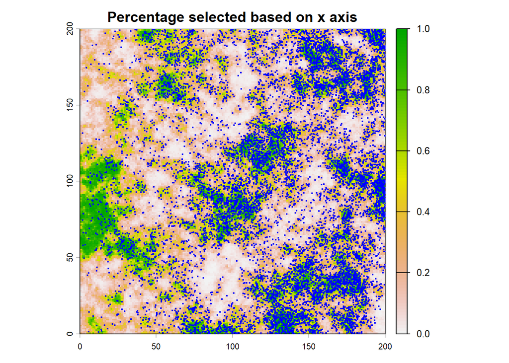

```r
plot(LAM_lgt_R, main="Percentage selected based on x axis", col= cols)
points(samp_ppp, cex = 0.3, pch=19, col='blue')
```

#### 4.2.2 Bias based on spatial covariate

In this other case, we determine that a new spatial covariate, like proximity to cities, could determine detect more individuals, so more proximity to cities determine higher probability of detect presence of individuals.

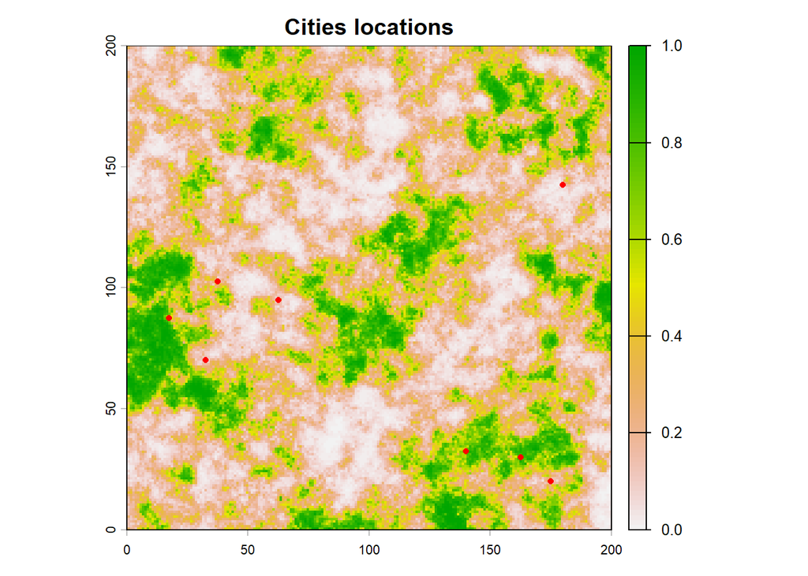

```r
#Determine some cities on the simulated area
set.seed(1234)
city_dots <- randomSamp(n= 8, xrange = c(0,200), yrange = c(0,200), 5)
v.city_dots <- vect(city_dots, geom = c("x", "y"))

#Visualize the cities on the simulated area
plot(LAM_lgt_R, main="Cities locations", col= cols)
points(v.city_dots, col='red', pch=16)
```

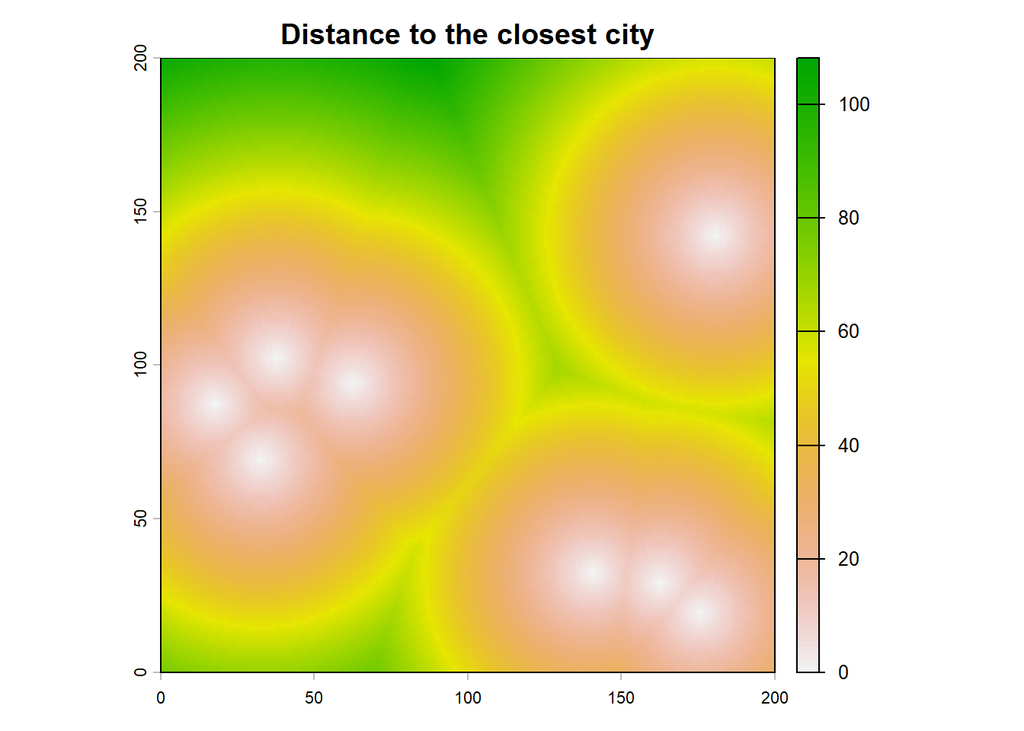

```r
#Calculate the distance of each cell to the closest city
r.city_dots <- rasterize(v.city_dots, LAM_lgt_R, background = 0)
d.city_dots <- distance(r.city_dots, target = 0, exclude = NULL, method="haversine")
plot(d.city_dots, main="Distance to the closest city", col= cols)
```